# EE0848 Machine Learning for SP - Week 1

## Week 1: Introduction

EE0848 Machine Learning for Signal Processing

## Today

**Syllabus**

Course expectations, weekly plan, assessment structure.

**Course overview**

What machine learning is and why it matters.

**Machine learning types**

Supervised, unsupervised, and reinforcement learning.

**ML workflow**

From problem definition to deployment.

## Weekly Schedule

| Week | Topic | Lecture (2 hours) |
| --- | --- | --- |
| 1 | Introduction to ML | What is ML? Types of ML. Course overview. |
| 2 | Supervised Learning: Linear Regression | Simple linear regression, multiple linear regression. Model fitting (least squares). Gradient descent. Model evaluation (MSE, R-squared). |
| 3 | Supervised Learning: Logistic Regression | Classification problems. Sigmoid function. Logistic regression model. Maximum likelihood estimation. Decision boundaries. |
| 4 | Model Evaluation and Selection | Bias-variance tradeoff. Overfitting and underfitting. Cross-validation (k-fold). Performance metrics (accuracy, precision, recall, F1-score, ROC curve, AUC). Choosing appropriate metrics. |
| 5 | Regularization | Ridge regression (L2 regularization). Lasso regression (L1 regularization). Elastic Net. Mitigating overfitting and improving generalization. |
| 6 | Supervised Learning: Trees | Decision trees. Entropy, information gain. Feature importance. |
| 7 | Ensemble Methods | Bagging. Random Forests. |
| 8 | Midterm Exam | Covering weeks 1-7. |
| 9 | Supervised Learning: Boosting | Gradient boosting. AdaBoost, XGBoost, LightGBM. |
| 10 | Unsupervised Learning: Clustering | K-means clustering. Hierarchical clustering. Evaluation metrics. |
| 11 | Reinforcement Learning | Introduction to RL. Key concepts: agents, environments, states, actions, rewards. |
| 12 | Neural Networks: Introduction | Perceptron. MLP. Activation functions (ReLU, sigmoid, tanh). Backpropagation. Data normalization and initialization. |
| 13 | Neural Networks: CNNs | Convolutional layers. Pooling layers. Architectures (LeNet, AlexNet, etc.). Image classification. Bias in image recognition. |
| 14 | Transformers | Motivation: limitations of RNNs. Core idea: “attention”. Self-attention. Multi-headed attention. Positional encoding. Encoder-decoder structure. Applications: BERT, GPT. |

## Assessments

30% Project

25% Midterm Exam

30% Final Exam

15% Quizzes

## Final Project

Students will work **individually** or in **small groups of at most 3** on a real-world machine learning project.

**Choose a dataset**

Select a dataset suitable for a machine learning question.

**Formulate a problem**

Define the prediction, classification, clustering, or analysis goal.

**Apply ML techniques**

Train appropriate models and tune them responsibly.

**Report findings**

Evaluate models and present the results in a report and short presentation.

## Learning Outcomes

By the end of the course, students should be able to:

- Explain key machine learning concepts and learning types.
- Implement and evaluate regression and classification models.
- Use metrics, cross-validation, and regularization to optimize models.
- Implement bagging and boosting techniques for improved accuracy.
- Perform clustering on datasets.
- Design basic MLP and CNN architectures for deep learning applications.

## Recommended Books and Resources

- **Introduction to Machine Learning with Python**  
  Andreas C. Müller and Sarah Guido
- **Machine Learning with PyTorch and Scikit-Learn**  
  Sebastian Raschka, Yuxi (Hayden) Liu, and Vahid Mirjalili
- **The Elements of Statistical Learning**  
  Trevor Hastie, Robert Tibshirani, and Jerome Friedman
- **Deep Learning**  
  Ian Goodfellow, Yoshua Bengio, and Aaron Courville
- **Online resources:** [scikit-learn](https://scikit-learn.org/stable/), [PyTorch](https://pytorch.org/), [Kaggle](https://www.kaggle.com/), [Fast.ai](https://www.fast.ai/), [Towards Data Science](https://towardsdatascience.com/)

## Reference Books

[figure not shown]

[figure not shown]

[figure not shown]

## Python Tools for Machine Learning

Python is the primary software environment for this course.

**Interactive work**

Jupyter Notebook and Google Colab.

**Numerical computing**

NumPy, pandas, and scientific Python tools.

**Machine learning**

scikit-learn for classical ML, PyTorch for deep learning.

## Software & Tools for Machine Learning

| Category | Tools |
| --- | --- |
| Language | [Python](https://www.python.org/) |
| Notebooks | [Jupyter Notebook](https://jupyter.org/), [Google Colab](https://colab.research.google.com/) |
| Data | [NumPy](https://numpy.org/), [pandas](https://pandas.pydata.org/) |
| ML | [scikit-learn](https://scikit-learn.org/), [PyTorch](https://pytorch.org/) |
| Visualization | [Matplotlib](https://matplotlib.org/), [Seaborn](https://seaborn.pydata.org/) |

## Machine Learning Introduction

## What is Machine Learning?

Machine learning is a subfield of artificial intelligence (AI) that focuses on enabling systems to:

**Learn from data**

**Identify patterns**

**Make decisions with minimal human intervention**

## Why is Machine Learning Important Today?

- Explosion of data (**Big Data**)
- Increased computing power
- Advancements in algorithms
- Demand for automation and intelligent systems
- Wide range of applications

## Machine Learning vs. Traditional Programming

| Traditional Programming | Machine Learning |
| --- | --- |
| Programmer writes explicit rules. | Algorithm learns rules from data. |
| Input data + rules → output results. | Input data + desired outputs → learned model. |
| Best when logic is known and stable. | Best when patterns are complex or hard to hand-code. |

## Types of Machine Learning

**Supervised Learning**

Learns from labeled examples.

**Unsupervised Learning**

Finds structure in unlabeled data.

**Reinforcement Learning**

Learns through actions, environments, and rewards.

## Supervised Learning

Learns from **labeled data**: input-output pairs.

- **Goal:** predict the output for new, unseen inputs.
- **Classification:** predict a category.
- **Regression:** predict a numeric value.
- **Examples:** image classification, spam detection, house price prediction.

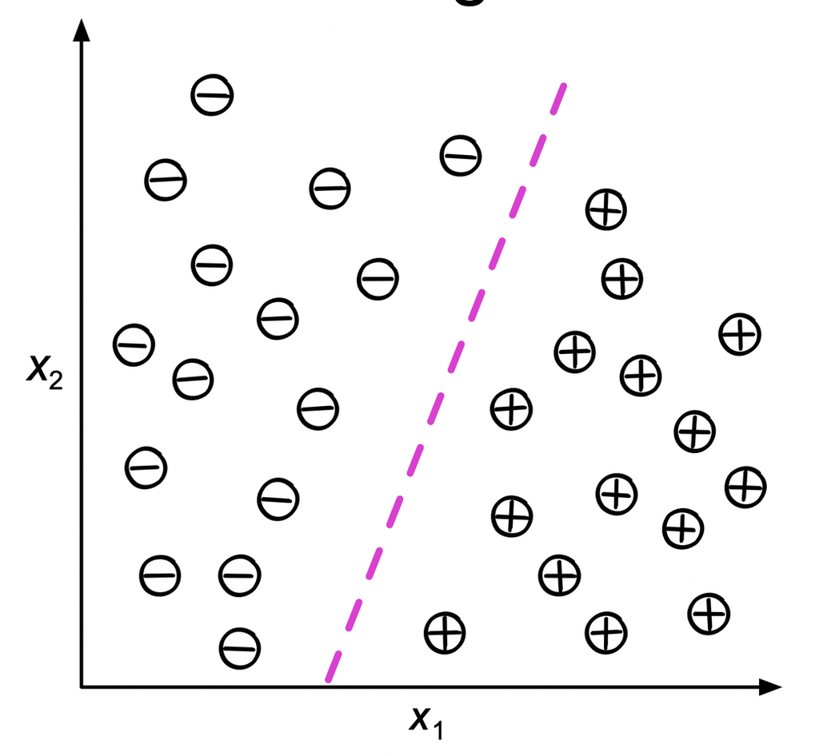

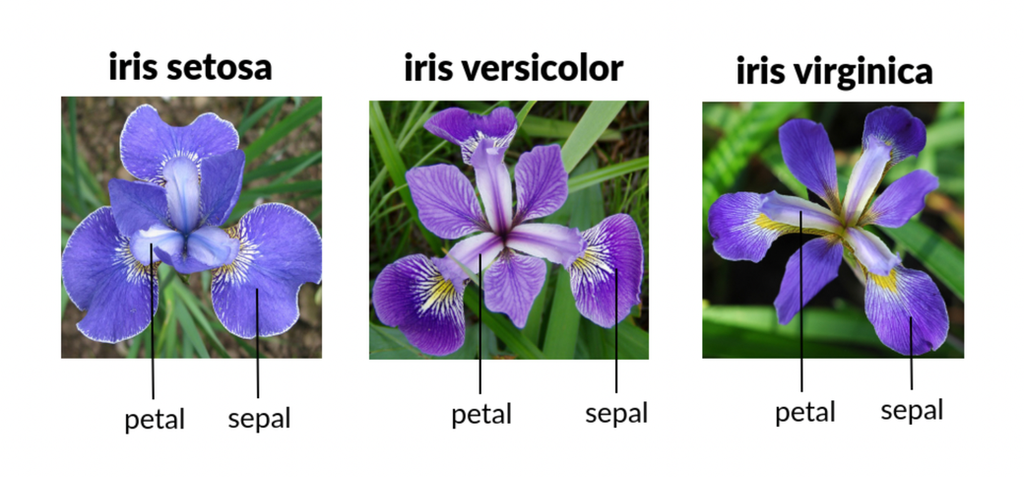

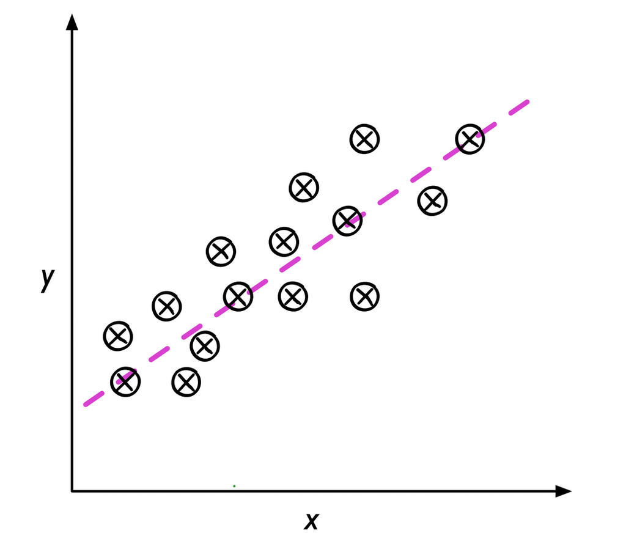

## Supervised Learning: Key Concepts

- **Training data:** examples used to learn.
- **Features:** input variables.
- **Labels:** correct outputs/classes.
- **Model:** learned mapping from features to labels.

Example: Fisher’s Iris dataset contains 150 iris specimens, 50 from each of three species.

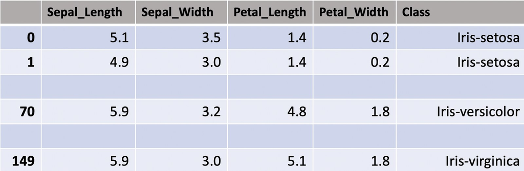

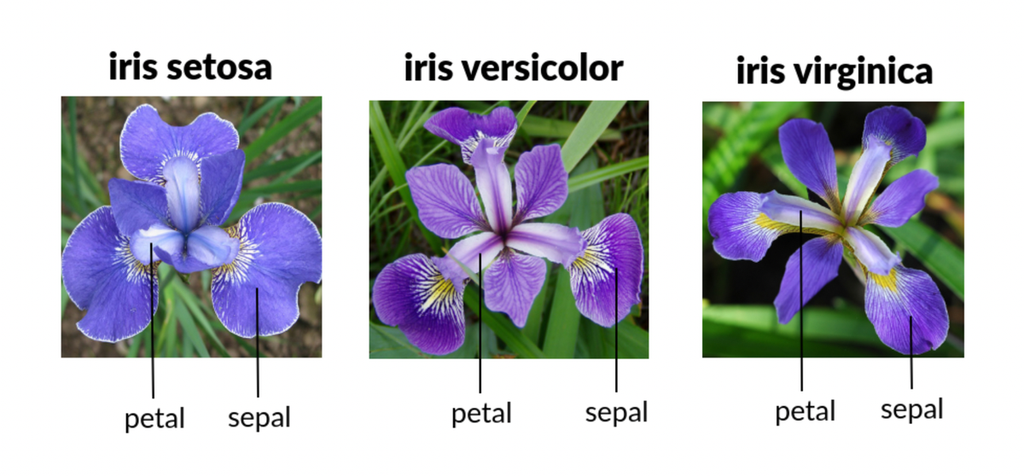

## Supervised Learning: Example

**Task:** Predict house price based on size.

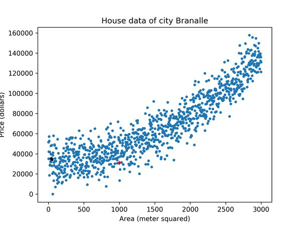

## Unsupervised Learning

Learns from **unlabeled data**: inputs only, no target outputs.

- **Goal:** discover hidden patterns, structures, and relationships.
- **Examples:** customer segmentation, anomaly detection, dimensionality reduction.

## Unsupervised Learning: Example

**Task:** Group similar customers together.

- **Features:** customer demographics, purchase history, etc.
- **Model:** K-means clustering.

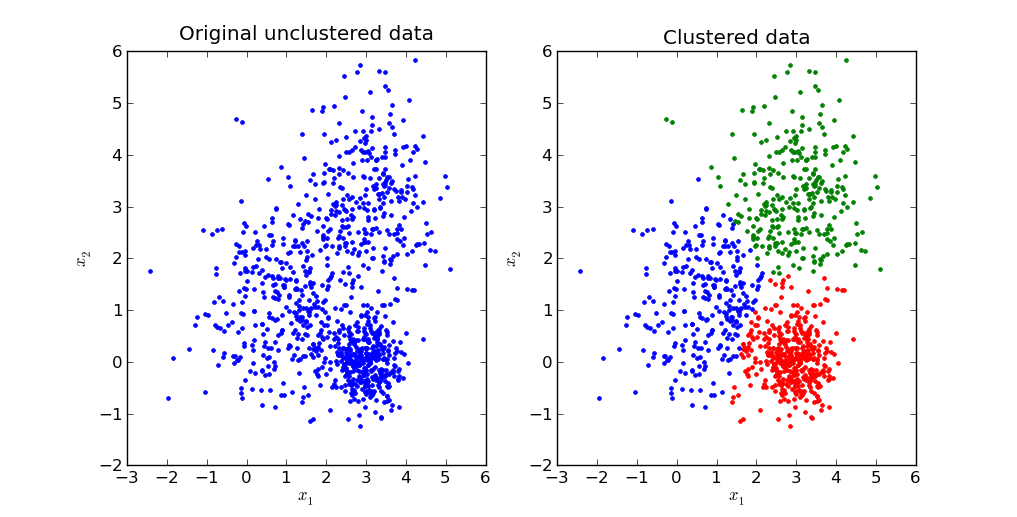

## Reinforcement Learning

An **agent** learns to interact with an **environment** by taking actions and receiving rewards.

- **Goal:** learn an optimal policy, a sequence of actions that maximizes cumulative reward.
- **Examples:** game playing, robotics, resource management, reasoning models.

## Reinforcement Learning: Core Terms

- **Agent:** learner and decision-maker.
- **Environment:** world the agent interacts with.
- **State:** current situation.
- **Action:** what the agent does.
- **Reward:** feedback from the environment.

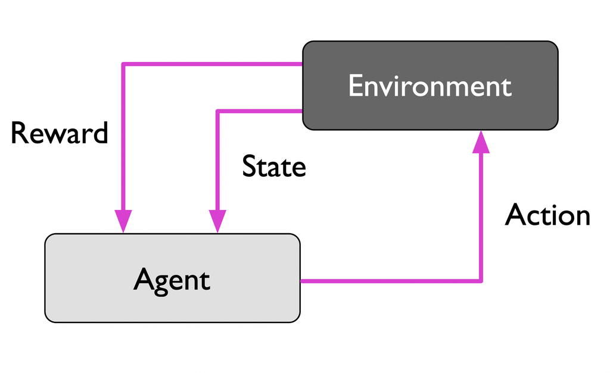

## Reinforcement Learning Example: Robot Vacuum Cleaner

- **Agent:** the robot vacuum cleaner.
- **Environment:** a room with dust and obstacles.
- **State:** current position and cleanliness of the surroundings.
- **Actions:** move left/right/forward/backward, clean, stop.
- **Rewards:**
  - +10 for cleaning a dusty spot
  - -5 for hitting an obstacle
  - -1 for moving without finding dust
  - -5 for revisiting recently cleaned areas

## Reinforcement Learning: Atari Breakout

Example video: **Google DeepMind’s Deep Q-learning playing Atari Breakout**

[Open on YouTube](https://www.youtube.com/watch?v=V1eYniJ0Rnk&ab_channel=TwoMinutePapers)

[figure not shown]

## Applications of Machine Learning

**Self-driving cars**

**Medical diagnosis**

**Fraud detection**

**Recommendation systems**

## The Machine Learning Workflow

1 **Problem Definition**

2 **Data Collection & Preparation**

3 **Model Selection**

4 **Training**

5 **Evaluation**

6 **Tuning**

7 **Deployment**

## Step 1: Problem Definition

- Clearly define the problem you want to solve.
- What are your goals and objectives?
- What type of ML problem is it?
  - Classification
  - Regression
  - Clustering
- What data do you need?

## Step 2: Data Collection and Preparation

- Gather data from various sources.
- Clean and preprocess the data:
  - handle missing values
  - detect outliers
  - scale features
  - transform data
- Split data into training, validation, and testing sets.

## Step 3: Model Selection

Choose an appropriate ML algorithm based on the problem and data.

Consider:

- type of problem: supervised or unsupervised
- data characteristics
- interpretability
- computational resources

## Step 4: Model Training

- Feed the training data to the chosen algorithm.
- The algorithm learns patterns and relationships in the data.
- Model parameters are adjusted to minimize the error or loss function.

## Step 5: Model Evaluation

- Assess the model’s performance on validation/test data.
- Use appropriate evaluation metrics:
  - accuracy
  - precision
  - recall
  - F1-score
  - mean squared error (MSE)
- Determine whether the model meets the desired performance goals.

## Step 6: Model Tuning

- Fine-tune model hyperparameters to improve performance.
- Use techniques like cross-validation to find good hyperparameter settings.
- Iterate between training, evaluation, and tuning.

## Step 7: Model Deployment

- Integrate the trained model into a real-world application or system.
- Monitor model performance over time.
- Retrain the model periodically with new data.

## End-to-End Machine Learning Pipeline

Feature Extraction and Scaling  
Feature Selection  
Dimensionality Reduction  
Sampling

Model Selection  
Cross-Validation  
Performance Metrics  
Hyperparameter Optimization

Raw Data

Labels

Preprocessing

Split the data into train and test sets

Training Set

Labels

Learning Algorithm

Learning/Training

Repeat if not satisfied with the model

Output ŷ

Compare model outputs to targets

Learned Model

Test Set

Labels y

Final Model

Model Evaluation

New Data

Labels  
(Predicted)

Model deployment

## Data Concepts

- **Features:** input variables used for prediction.
- **Labels/Targets:** output variables to be predicted.
- **Training set:** data used to train the model.
- **Validation set:** data used to tune hyperparameters.
- **Test set:** data used to evaluate final performance.

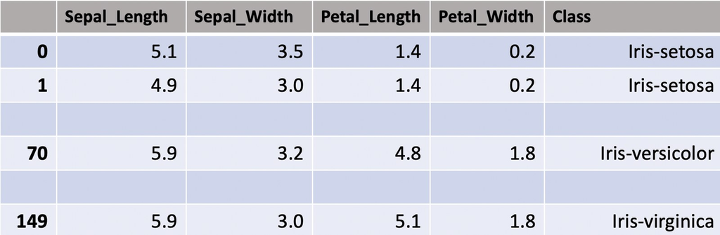

Example: Fisher’s Iris dataset.